# 基于因子分析和聚类分析的北交所股票投资价值研究

狗熊会

案例难度：

案例背景：2021年11月15日，北交所正式开市，截至2021年12月11日共有82只个股。它们行业新，规模小，是一只浩浩荡荡但同时嗷嗷待哺的队伍，仍需要在市场中大浪淘沙，投资者面临的风险不容小觑。因此，本案例通过对北交所上市股票的行情指标与公司基本面指标进行因子分析，并根据提取出的五大公因子对北交所股票进行聚类分析，为不同类型的投资者提供投资建议。

案例数据来自于财汇金融大数据终端北交所股票的相关数据，包括2021年12月6日至11日5个交易日的9个日行情指标与10个2021年第三季度公司基本面指标。其中，9个行情指标分别为开盘价、收盘价、均价、最高价、最低价、振幅、周涨跌幅、换手率、成交量，计算5个交易日的指标平均值作为各项行情指标的取值。10个公司基本面指标分别为总资产报酬率、净资产报酬率、销售毛利率、销售净利率、流动比率、速动比率、资产负债率、总资产同比增长率、净资产同比增长率、存货周转率。

详见本案例推文：

这个案例的学习目标包括：用python进行因子分析和聚类分析，雷达图的绘制。

# 准备工作

```python
#基本的数据分析与画图包
import numpy as np
import pandas as pd
from matplotlib import pyplot as plt
import seaborn as sns
import math #雷达图用

#因子分析、聚类分析需要的包
from sklearn.preprocessing import StandardScaler,MinMaxScaler #标准化
from factor_analyzer import FactorAnalyzer #因子分析模型
from factor_analyzer.factor_analyzer import calculate_kmo,calculate_bartlett_sphericity #因子分析检验
from sklearn.decomposition import FactorAnalysis #因子分析包
from sklearn.cluster import KMeans # Kmeans聚类
from sklearn.metrics import silhouette_score #轮廓系数
plt.rcParams['font.family']="SimHei" #matplot展示中文
plt.rcParams['axes.unicode_minus'] =False #减号unicode编码

#忽略warning信息
import warnings
warnings.filterwarnings("ignore")
```

# 任务一

读入数据，对所有的连续型变量绘制相关系数图并解读。

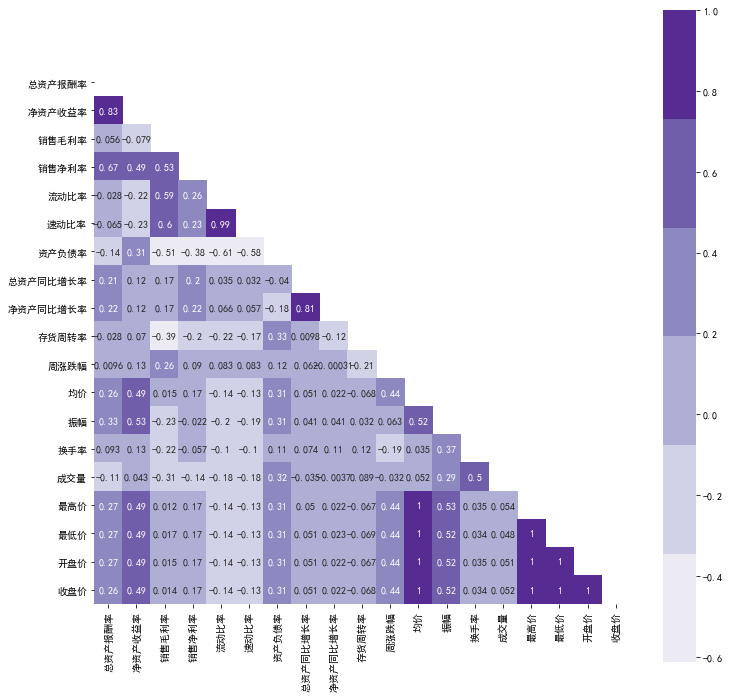

```python
#读入初始数据
res=pd.read_csv("北交所股票分析数据.csv",index_col="证券代码")

#绘制数据的相关系数图
corr=res.corr()
plt.figure(figsize=(12, 12))
#掩盖掉上面的三角形
mask=np.zeros_like(corr)
for i in range(len(mask)):
    for j in range(i,len(mask)):
        mask[i][j] = True
#绘制相关系数图
sns.heatmap(corr,mask=mask,vmax=1,square=True, cmap=sns.color_palette("Purples"),annot=True)
plt.show()
```

解读：由相关系数图可知，多个变量之间存在极高的相关性，需要进行降维。举例而言，由于股票在每日的价格波动不会太高，所以其最高价、最低价、均价、开盘价、收盘价之间相差不会太大，这就导致这几个变量之间高度相关。

# 任务二

首先，通过Bartlett和KMO检验，来确定该数据是否可以进行因子分析；其次，通过绘制碎石图，判断选取的公因子个数。

```python
#对数据进行标准化
#定义标准化模型
scalar1=StandardScaler()
#将数据标准化
d=pd.DataFrame(scalar1.fit_transform(res.copy()))
d.index=res.index
d.columns=res.columns

#进行Bartlett检验
chi_square_value,p_value=calculate_bartlett_sphericity(d)
#Bartlett检验的值和p值
print('Bartlett检验的值和p值: ',chi_square_value, p_value)
#进行KMO检验
kmo_all,kmo_model=calculate_kmo(d)
#KMO值
print('KMO值: ',kmo_model)
```

```
Bartlett检验的值和p值:  3404.752515627804 0.0
KMO值:  0.6517121884289065
```

解读：在对数据进行标准化后，数据均通过了Bartlett检验和KMO检验，说明变量之间的确存在一定的相关性，可以用因子分析提取出公共因子。

绘制碎石图。

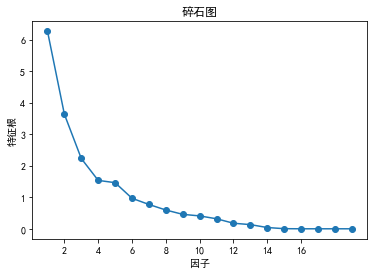

```python
#建立因子分析模型，采用最大方差旋转法
fa=FactorAnalyzer(rotation="varimax")
fa.fit(d)
#得到特征值和特征向量
ev,v=fa.get_eigenvalues()
#用特征值绘制碎石图
plt.figure()
#设置x轴范围
lst=list(range(0,18,2))
plt.xticks(lst)
#绘制特征值
plt.plot(range(1,d.shape[1]+1),ev,"-o")
plt.title('碎石图')
plt.xlabel('因子')
plt.ylabel('特征根')
plt.show()
```

解读：从碎石图中，可以发现，共有5个因子特征根大于1，因此选取因子数量为5。

# 任务三

进行因子分析，采取最大方差旋转法，给出各因子特征值占比和累计占比等信息。

```python
#选取5个因子进行建模
fa=FactorAnalyzer(rotation="varimax",n_factors=5)
#拟合标准化后的数据
fa.fit(d)
#查看特征值占比
sve=pd.DataFrame(fa.get_factor_variance())
sve.index=["因子特征值","特征值占比","特征值累积占比"]
sve.columns=["因子"+str(i+1) for i in range(5)]
sve
```

|  | 因子1 | 因子2 | 因子3 | 因子4 | 因子5 |
| --- | --- | --- | --- | --- | --- |
| 因子特征值 | 5.563863 | 3.052473 | 2.273165 | 1.683564 | 1.427088 |
| 特征值占比 | 0.292835 | 0.160656 | 0.119640 | 0.088609 | 0.075110 |
| 特征值累积占比 | 0.292835 | 0.453491 | 0.573132 | 0.661740 | 0.736850 |

解读：可以看出，当选取五个因子时，特征根累计占比达到了73.69%，超过70%，说明因子数量的选取有一定的合理性。

# 任务四

给出因子载荷估计值并对其进行可视化。

```python
#得到因子载荷矩阵
tmp1=pd.DataFrame(fa.loadings_)
tmp1.index=res.columns
tmp1.columns=["因子"+str(i+1) for i in range(5)]
tmp1
```

|  | 因子1 | 因子2 | 因子3 | 因子4 | 因子5 |
| --- | --- | --- | --- | --- | --- |
| 总资产报酬率 | 0.119889 | 0.014513 | 0.979299 | 0.115985 | 0.040368 |
| 净资产收益率 | 0.377016 | -0.203189 | 0.787037 | 0.035749 | 0.161465 |
| 销售毛利率 | 0.072677 | 0.678942 | 0.108091 | 0.146348 | -0.369761 |
| 销售净利率 | 0.100016 | 0.361368 | 0.674567 | 0.151483 | -0.195448 |
| 流动比率 | -0.074071 | 0.966342 | -0.048694 | -0.027756 | 0.014330 |
| 速动比率 | -0.064746 | 0.935649 | -0.077630 | -0.029601 | 0.011704 |
| 资产负债率 | 0.298345 | -0.646608 | -0.124009 | -0.086221 | 0.221463 |
| 总资产同比增长率 | 0.034219 | 0.043920 | 0.099683 | 0.792373 | 0.015068 |
| 净资产同比增长率 | -0.003112 | 0.096151 | 0.102135 | 0.987098 | 0.053392 |
| 存货周转率 | -0.101204 | -0.296672 | -0.025950 | -0.067328 | 0.190896 |
| 周涨跌幅 | 0.483332 | 0.116751 | -0.048001 | 0.029517 | -0.200968 |
| 均价 | 0.983886 | -0.060382 | 0.144001 | 0.010577 | 0.058452 |
| 振幅 | 0.455825 | -0.165037 | 0.249802 | 0.001023 | 0.509052 |
| 换手率 | -0.027757 | -0.060665 | 0.070675 | 0.084856 | 0.703014 |
| 成交量 | 0.033266 | -0.173700 | -0.096998 | -0.002717 | 0.569754 |
| 最高价 | 0.983571 | -0.061465 | 0.144398 | 0.010001 | 0.061875 |
| 最低价 | 0.983802 | -0.059020 | 0.144512 | 0.010941 | 0.055109 |
| 开盘价 | 0.983381 | -0.060192 | 0.145686 | 0.010503 | 0.059301 |
| 收盘价 | 0.984043 | -0.060260 | 0.142703 | 0.010726 | 0.058207 |

绘制因子载荷绝对值热力图。

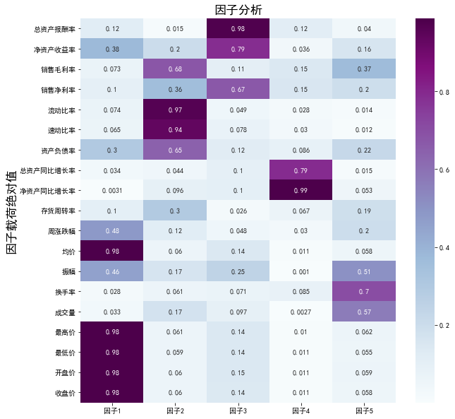

```python
tmp2=pd.DataFrame()
for i in tmp1.columns:
    tmp2[i]=tmp1[i].apply(lambda x:abs(x))
plt.figure(figsize=(10,10))
ax = sns.heatmap(tmp2, annot=True, cmap="BuPu")
ax.yaxis.set_tick_params(labelsize=10)
plt.title('因子分析', fontsize='xx-large')
plt.ylabel('因子载荷绝对值', fontsize='xx-large')
plt.show()
```

解读：结合因子载荷绝对值热力图与因子载荷本身值的正负，对各个因子命名如下：（1）因子1——价格因子；（2）因子2——偿债因子；（3）因子3——盈利因子；（4）因子4——成长因子；（5）因子5——交易因子。

# 任务五

在建立完因子模型后，首先，计算每只股票在不同因子上的得分；其次，为了方便画雷达图，将每只股票的因子得分归一化。

```python
#计算因子得分
ans=pd.DataFrame(fa.transform(d))
ans.index=res.index
ans.columns=["价格因子","偿债因子","盈利因子","成长因子","交易因子"]
ans
```

| 证券代码 | 价格因子 | 偿债因子 | 盈利因子 | 成长因子 | 交易因子 |
| --- | --- | --- | --- | --- | --- |
| 831305 | -0.066731 | 2.605231 | 2.825412 | 0.280523 | 0.467356 |
| 837212 | -0.418548 | -0.443893 | 1.830418 | -0.821543 | 0.528740 |
| 831726 | -0.454237 | 0.481625 | 1.786385 | -0.654587 | -0.046773 |
| 836826 | -0.607707 | -0.166642 | 1.433250 | -0.835556 | 1.459002 |
| 838275 | -0.687717 | 2.142198 | 1.836463 | 0.597201 | 0.204300 |
| ... | ... | ... | ... | ... | ... |
| 835670 | 0.359063 | 4.004149 | -1.785126 | -0.893331 | 0.985601 |
| 430090 | -0.604049 | -0.263036 | -1.402181 | 0.995127 | 2.581496 |
| 430198 | 0.009010 | 0.827302 | -1.711154 | -0.329594 | -0.795220 |
| 832171 | 0.026951 | -0.277686 | -1.778665 | -0.284682 | 1.593152 |
| 835508 | -0.038913 | 0.096491 | -1.898740 | -0.549761 | 0.193828 |

66 rows × 5 columns

将因子得分投射到1-5，方便画雷达图。

```python
ans_copy=ans.copy()
scalar2=MinMaxScaler(feature_range=(1,5))
#转化成dataframe
radars=pd.DataFrame(scalar2.fit_transform(ans_copy))
radars.index=ans_copy.index
radars.columns=ans_copy.columns
```

# 任务六

利用因子得分进行K-means聚类。为判断类数，绘制碎石图：分别在随机数种子0-99下进行聚类，计算SSE的均值作为碎石图的纵轴。

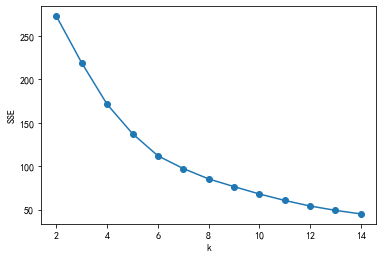

```python
#对因子得分进行标准化，方便后续聚类建模
scalar3=StandardScaler()
ans=pd.DataFrame(scalar3.fit_transform(ans_copy))
ans.index=ans_copy.index
ans.columns=ans_copy.columns

#计算SSE，从而绘制碎石图
SSE=[]
for k in range(2,15):
    cnt=0
    #随机数种子从0取到99，计算平均值
    for i in range(100):
        estimator=KMeans(n_clusters=k,random_state=i)
        estimator.fit(ans)
        cnt+=estimator.inertia_
    SSE.append(cnt/100)
#绘制碎石图
X = range(2,15)
plt.figure()
plt.xlabel('k')
plt.ylabel('SSE')
plt.plot(X,SSE,'o-')
plt.show()
```

解读：一般来说，我们会选取碎石图变化比较陡峭的点作为聚类的类数，但是本案例的碎石图在各个类别数均比较平缓，最后，结合案例目标，我们选取K=4建立聚类模型。

# 任务七

在K=4下进行K-means聚类，对各类别进行计数并绘制柱状图。

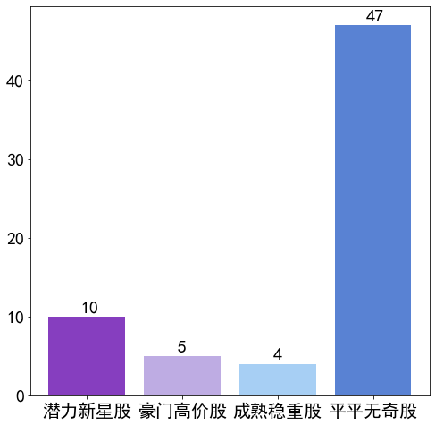

```python
#在K为4，随机数种子为99下进行K-means聚类
estimator=KMeans(n_clusters=4,random_state=99)
estimator.fit(ans)

#得到分类标签，将其存储
s=pd.Series(estimator.labels_)
s.index=d.index
res["类别"]=s

#对各类别进行计数
counts=res.类别.value_counts().sort_index()
counts=counts.reindex([0,1,3,2])
counts_res=counts.values
#根据计数绘制柱状图
plt.figure(figsize=(8,8))
plt.bar(x=[0,1,2,3],height=counts,color=["#680DB0","#AE97DD","#91C4F2","#3063C9"],alpha=0.8)
minus=[-0.07,-0.05,-0.05,-0.07]
#添加标签
for i in range(4):
    plt.text(i+minus[i],counts_res[i]+0.5,counts_res[i],size=20)
#设置x，y轴标签
plt.xticks(range(4),["潜力新星股","豪门高价股","成熟稳重股","平平无奇股"],size=20)
plt.yticks(size=20)
plt.show()
```

解读：对各类型股票进行计数，可以发现大多数股票都属于“平平无奇股”，只有少数股票有自己的突出优势，这也符合股市中大部分股票都较为平庸，只有少数股票能脱颖而出的现状，说明聚类结果有一定的合理性。

# 任务八

首先，计算各聚类中心并进行归一化；接着，定义绘制雷达图的函数，对归一化的各聚类中心进行雷达图可视化。

```python
#得到最优模型下的中心
centers=pd.DataFrame(estimator.cluster_centers_)
centers.index=range(4)
centers.columns=ans.columns
centers=centers.reindex([0,3,1,2])
centers.index=["潜力新星股","豪门高价股","成熟稳重股","平平无奇股"]
#将各类中心归一化至1-5
scalar=MinMaxScaler(feature_range=(1,5))
centers_scaled=pd.DataFrame(scalar.fit_transform(centers.copy()))
centers_scaled.index=["类别"+ str(i) for i in range(1,5)]
centers_scaled.columns=centers.columns
centers
```

|  | 价格因子 | 偿债因子 | 盈利因子 | 成长因子 | 交易因子 |
| --- | --- | --- | --- | --- | --- |
| 潜力新星股 | -0.252887 | -0.066007 | -0.057647 | 2.098165 | 0.517228 |
| 豪门高价股 | 3.566479 | -0.470388 | 0.358850 | -0.198984 | 0.522228 |
| 成熟稳重股 | 0.048522 | 2.942395 | 0.257468 | -0.241146 | 0.318947 |
| 平平无奇股 | -0.254886 | -0.258944 | -0.045665 | -0.403829 | -0.188424 |

定义雷达图函数。

```python
def make_spider(df, row, color, title):
    #得到列名，即雷达图所需指标
    pi=math.pi
    categories=list(df)[0:]
    N = len(categories)

    #计算角度
    angles = [n / float(N) * 2 * pi for n in range(N)]
    #补原点
    angles += angles[:1]
    #设置画图大小
    plt.rc('figure', figsize=(12, 12))

    ax = plt.subplot(1,1,1, polar=True)
    #使用极坐标
    ax.set_theta_offset(pi / 2)
    ax.set_theta_direction(-1)

    #设置xy轴标签
    ax.set_rlabel_position(0)
    plt.yticks(size=12)
    plt.xticks(angles[:-1], df.columns,  size=20)

    #得到需要的一整行数据
    values=df.reset_index().loc[row].values.tolist()[1:]
    values += values[:1]
    #根据数据画图
    plt.plot(angles, values, color = color, linewidth=1, linestyle='solid',label=title)
    plt.fill(angles, values, color = color, alpha = 0.8)
```

绘制四个类别聚类中心的雷达图。

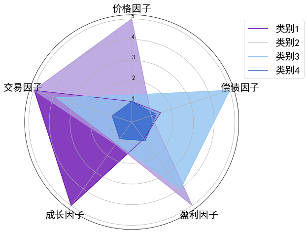

```python
plt.figure(figsize=(8,8))
make_spider(centers_scaled,0,"#680DB0","类别1")
make_spider(centers_scaled,1,"#AE97DD","类别2")
make_spider(centers_scaled,2,"#91C4F2","类别3")
make_spider(centers_scaled,3,"#3063C9","类别4")
#增加图例
plt.legend(fontsize=20,bbox_to_anchor=(1,1))
plt.show()
```

# 任务九

给出一个具体股票的雷达图，以长虹能源为例。

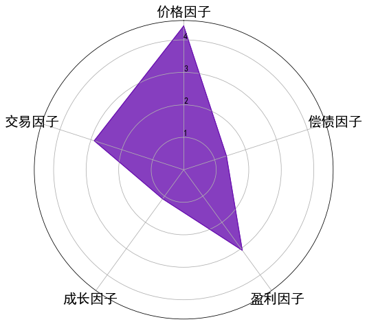

```python
plt.figure(figsize=(8,8))
#把雷达图用数据（1-5范围内的因子得分）和其他股票数据进行拼接
res_radars=res.join(radars,how="inner",on="证券代码").reset_index()
res_radars_factor=res_radars[['价格因子','偿债因子','盈利因子','成长因子','交易因子']]
#调用自定义的雷达图函数，绘制“长虹能源”的因子得分雷达图
make_spider(res_radars_factor,res_radars[res_radars['证券代码']==836239].index[0],"#680DB0","长虹能源因子得分雷达图")
```

解读：长虹能源的特征和“豪门高价股”的特征基本吻合。